# Risk Factor Analysis

## Outcome Variable

**Outcome Variable:** stunted

## Predictor Variables

**Intervention Variable:** birthlen

**Adjustment Set:**

unadjusted

## Stratifying Variables

The analysis was stratified on these variable(s):

- agecat
- studyid
- country

## Data Summary

| agecat | studyid | country | birthlen | stunted | n_cell | n |
| --- | --- | --- | --- | --- | --- | --- |
| Birth | ki0047075b-MAL-ED | BANGLADESH | >=0 | 0 | 39 | 257 |
| Birth | ki0047075b-MAL-ED | BANGLADESH | >=0 | 1 | 0 | 257 |
| Birth | ki0047075b-MAL-ED | BANGLADESH | <-3 | 0 | 0 | 257 |
| Birth | ki0047075b-MAL-ED | BANGLADESH | <-3 | 1 | 9 | 257 |
| Birth | ki0047075b-MAL-ED | BANGLADESH | [-3–2) | 0 | 0 | 257 |
| Birth | ki0047075b-MAL-ED | BANGLADESH | [-3–2) | 1 | 38 | 257 |
| Birth | ki0047075b-MAL-ED | BANGLADESH | [-2–1) | 0 | 83 | 257 |
| Birth | ki0047075b-MAL-ED | BANGLADESH | [-2–1) | 1 | 0 | 257 |
| Birth | ki0047075b-MAL-ED | BANGLADESH | [-1-0) | 0 | 88 | 257 |
| Birth | ki0047075b-MAL-ED | BANGLADESH | [-1-0) | 1 | 0 | 257 |
| 6 months | ki0047075b-MAL-ED | BANGLADESH | >=0 | 0 | 39 | 233 |
| 6 months | ki0047075b-MAL-ED | BANGLADESH | >=0 | 1 | 0 | 233 |
| 6 months | ki0047075b-MAL-ED | BANGLADESH | <-3 | 0 | 2 | 233 |
| 6 months | ki0047075b-MAL-ED | BANGLADESH | <-3 | 1 | 4 | 233 |
| 6 months | ki0047075b-MAL-ED | BANGLADESH | [-3–2) | 0 | 14 | 233 |
| 6 months | ki0047075b-MAL-ED | BANGLADESH | [-3–2) | 1 | 18 | 233 |
| 6 months | ki0047075b-MAL-ED | BANGLADESH | [-2–1) | 0 | 59 | 233 |
| 6 months | ki0047075b-MAL-ED | BANGLADESH | [-2–1) | 1 | 15 | 233 |
| 6 months | ki0047075b-MAL-ED | BANGLADESH | [-1-0) | 0 | 76 | 233 |
| 6 months | ki0047075b-MAL-ED | BANGLADESH | [-1-0) | 1 | 6 | 233 |
| 24 months | ki0047075b-MAL-ED | BANGLADESH | >=0 | 0 | 31 | 206 |
| 24 months | ki0047075b-MAL-ED | BANGLADESH | >=0 | 1 | 7 | 206 |
| 24 months | ki0047075b-MAL-ED | BANGLADESH | <-3 | 0 | 1 | 206 |
| 24 months | ki0047075b-MAL-ED | BANGLADESH | <-3 | 1 | 5 | 206 |
| 24 months | ki0047075b-MAL-ED | BANGLADESH | [-3–2) | 0 | 7 | 206 |
| 24 months | ki0047075b-MAL-ED | BANGLADESH | [-3–2) | 1 | 19 | 206 |
| 24 months | ki0047075b-MAL-ED | BANGLADESH | [-2–1) | 0 | 28 | 206 |
| 24 months | ki0047075b-MAL-ED | BANGLADESH | [-2–1) | 1 | 34 | 206 |
| 24 months | ki0047075b-MAL-ED | BANGLADESH | [-1-0) | 0 | 46 | 206 |
| 24 months | ki0047075b-MAL-ED | BANGLADESH | [-1-0) | 1 | 28 | 206 |

[output cut: 633 more lines]

The following strata were considered:

- agecat: 24 months, studyid: ki0047075b-MAL-ED, country: BANGLADESH
- agecat: 24 months, studyid: ki0047075b-MAL-ED, country: BRAZIL
- agecat: 24 months, studyid: ki0047075b-MAL-ED, country: INDIA
- agecat: 24 months, studyid: ki0047075b-MAL-ED, country: NEPAL
- agecat: 24 months, studyid: ki0047075b-MAL-ED, country: PERU
- agecat: 24 months, studyid: ki0047075b-MAL-ED, country: SOUTH AFRICA
- agecat: 24 months, studyid: ki0047075b-MAL-ED, country: TANZANIA, UNITED REPUBLIC OF
- agecat: 24 months, studyid: ki1000108-CMC-V-BCS-2002, country: INDIA
- agecat: 24 months, studyid: ki1000108-IRC, country: INDIA
- agecat: 24 months, studyid: ki1017093-NIH-Birth, country: BANGLADESH
- agecat: 24 months, studyid: ki1017093b-PROVIDE, country: BANGLADESH
- agecat: 24 months, studyid: ki1017093c-NIH-Crypto, country: BANGLADESH
- agecat: 24 months, studyid: ki1101329-Keneba, country: GAMBIA
- agecat: 24 months, studyid: ki1114097-CMIN, country: PERU
- agecat: 24 months, studyid: ki1114097-CONTENT, country: PERU
- agecat: 24 months, studyid: ki1119695-PROBIT, country: BELARUS
- agecat: 24 months, studyid: ki1126311-ZVITAMBO, country: ZIMBABWE
- agecat: 24 months, studyid: ki1135781-COHORTS, country: GUATEMALA
- agecat: 24 months, studyid: ki1135781-COHORTS, country: INDIA
- agecat: 24 months, studyid: ki1135781-COHORTS, country: PHILIPPINES
- agecat: 24 months, studyid: kiGH5241-JiVitA-3, country: BANGLADESH
- agecat: 24 months, studyid: kiGH5241-JiVitA-4, country: BANGLADESH
- agecat: 6 months, studyid: ki0047075b-MAL-ED, country: BANGLADESH
- agecat: 6 months, studyid: ki0047075b-MAL-ED, country: BRAZIL
- agecat: 6 months, studyid: ki0047075b-MAL-ED, country: INDIA
- agecat: 6 months, studyid: ki0047075b-MAL-ED, country: NEPAL
- agecat: 6 months, studyid: ki0047075b-MAL-ED, country: PERU
- agecat: 6 months, studyid: ki0047075b-MAL-ED, country: SOUTH AFRICA
- agecat: 6 months, studyid: ki0047075b-MAL-ED, country: TANZANIA, UNITED REPUBLIC OF
- agecat: 6 months, studyid: ki1000108-CMC-V-BCS-2002, country: INDIA
- agecat: 6 months, studyid: ki1000108-IRC, country: INDIA
- agecat: 6 months, studyid: ki1000109-EE, country: PAKISTAN
- agecat: 6 months, studyid: ki1000109-ResPak, country: PAKISTAN
- agecat: 6 months, studyid: ki1000304b-SAS-CompFeed, country: INDIA
- agecat: 6 months, studyid: ki1017093-NIH-Birth, country: BANGLADESH
- agecat: 6 months, studyid: ki1017093b-PROVIDE, country: BANGLADESH
- agecat: 6 months, studyid: ki1017093c-NIH-Crypto, country: BANGLADESH
- agecat: 6 months, studyid: ki1101329-Keneba, country: GAMBIA
- agecat: 6 months, studyid: ki1114097-CMIN, country: BRAZIL
- agecat: 6 months, studyid: ki1114097-CMIN, country: PERU
- agecat: 6 months, studyid: ki1114097-CONTENT, country: PERU
- agecat: 6 months, studyid: ki1119695-PROBIT, country: BELARUS
- agecat: 6 months, studyid: ki1126311-ZVITAMBO, country: ZIMBABWE
- agecat: 6 months, studyid: ki1135781-COHORTS, country: GUATEMALA
- agecat: 6 months, studyid: ki1135781-COHORTS, country: INDIA
- agecat: 6 months, studyid: ki1135781-COHORTS, country: PHILIPPINES
- agecat: 6 months, studyid: kiGH5241-JiVitA-3, country: BANGLADESH
- agecat: 6 months, studyid: kiGH5241-JiVitA-4, country: BANGLADESH
- agecat: Birth, studyid: ki0047075b-MAL-ED, country: BANGLADESH
- agecat: Birth, studyid: ki0047075b-MAL-ED, country: BRAZIL
- agecat: Birth, studyid: ki0047075b-MAL-ED, country: INDIA
- agecat: Birth, studyid: ki0047075b-MAL-ED, country: NEPAL
- agecat: Birth, studyid: ki0047075b-MAL-ED, country: PERU
- agecat: Birth, studyid: ki0047075b-MAL-ED, country: SOUTH AFRICA
- agecat: Birth, studyid: ki0047075b-MAL-ED, country: TANZANIA, UNITED REPUBLIC OF
- agecat: Birth, studyid: ki1000108-CMC-V-BCS-2002, country: INDIA
- agecat: Birth, studyid: ki1000108-IRC, country: INDIA
- agecat: Birth, studyid: ki1000109-EE, country: PAKISTAN
- agecat: Birth, studyid: ki1000109-ResPak, country: PAKISTAN
- agecat: Birth, studyid: ki1000304b-SAS-CompFeed, country: INDIA
- agecat: Birth, studyid: ki1017093-NIH-Birth, country: BANGLADESH
- agecat: Birth, studyid: ki1017093c-NIH-Crypto, country: BANGLADESH
- agecat: Birth, studyid: ki1101329-Keneba, country: GAMBIA
- agecat: Birth, studyid: ki1114097-CMIN, country: BANGLADESH
- agecat: Birth, studyid: ki1114097-CMIN, country: BRAZIL
- agecat: Birth, studyid: ki1114097-CMIN, country: PERU
- agecat: Birth, studyid: ki1114097-CONTENT, country: PERU
- agecat: Birth, studyid: ki1119695-PROBIT, country: BELARUS
- agecat: Birth, studyid: ki1126311-ZVITAMBO, country: ZIMBABWE
- agecat: Birth, studyid: ki1135781-COHORTS, country: GUATEMALA
- agecat: Birth, studyid: ki1135781-COHORTS, country: INDIA
- agecat: Birth, studyid: ki1135781-COHORTS, country: PHILIPPINES
- agecat: Birth, studyid: kiGH5241-JiVitA-3, country: BANGLADESH
- agecat: Birth, studyid: kiGH5241-JiVitA-4, country: BANGLADESH

### Dropped Strata

Some strata were dropped due to rare outcomes:

## Methods Detail

We’re interested in the causal parameters $E[Y_a]$ for all values of $a \in \mathcal{A}$. These parameters represent the mean outcome if, possibly contrary to fact, we intervened to set all units to have $A=a$. Under the randomization and positivity assumptions, these are identified by the statistical parameters $\psi_a=E_W[E_{Y|A,W}(Y|A=a,W)]$. In addition, we’re interested in the mean of $Y$, $E[Y]$ under no intervention (the observed mean). We will estimate these parameters by using SuperLearner to fit the relevant likelihood factors – $E_{Y|A,W}(Y|A=a,W)$ and $p(A=a|W)$, and then updating our likelihood fit using a joint TMLE.

For unadjusted analyses ($W=\{\}$), initial likelihoods were estimated using Lrnr_glm to estimate the simple $E(Y|A)$ and Lrnr_mean to estimate $p(A)$. For adjusted analyses, a small library containing Lrnr_glmnet, Lrnr_xgboost, and Lrnr_mean was used.

Having estimated these parameters, we will then use the delta method to estimate relative risks and attributable risks relative to a prespecified baseline level of $A$.

```
##          stunted
## birthlen  0
##   >=0     9
##   <-3     0
##   [-3--2) 0
##   [-2--1) 0
##   [-1-0)  0
##          stunted
## birthlen   0
##   >=0     10
##   <-3      0
##   [-3--2)  0
##   [-2--1)  0
##   [-1-0)   0
```

# Results Detail

## Results Plots

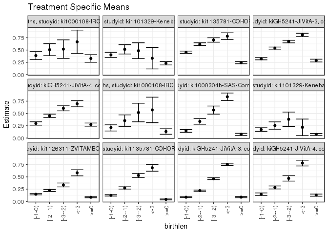

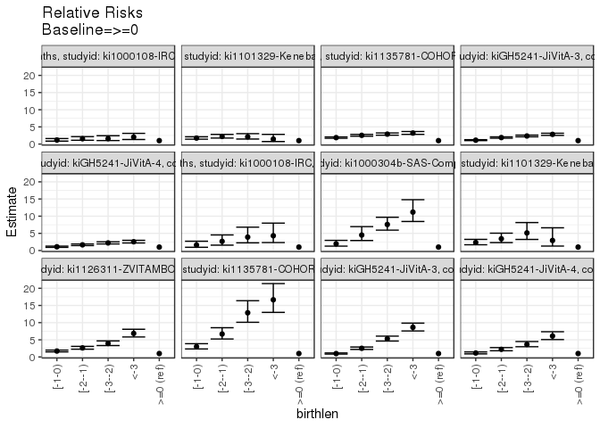

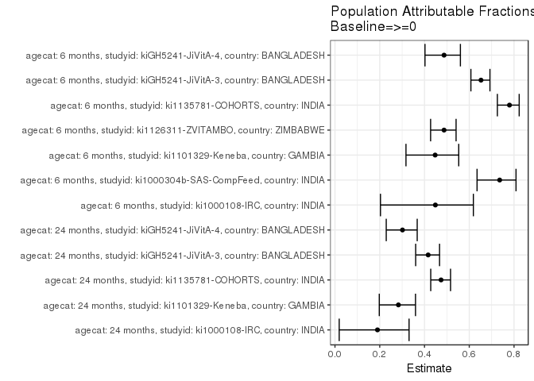

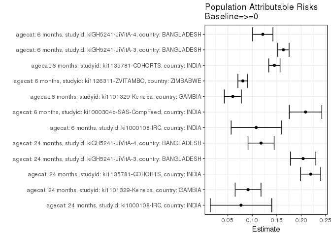

## Results Table

### Parameter: TSM

| agecat | studyid | country | intervention_level | baseline_level | estimate | ci_lower | ci_upper |
| --- | --- | --- | --- | --- | --- | --- | --- |
| 6 months | ki1000108-IRC | INDIA | >=0 | NA | 0.1328671 | 0.0771620 | 0.1885722 |
| 6 months | ki1000108-IRC | INDIA | <-3 | NA | 0.5714286 | 0.3118673 | 0.8309899 |
| 6 months | ki1000108-IRC | INDIA | [-3–2) | NA | 0.5185185 | 0.3298057 | 0.7072313 |
| 6 months | ki1000108-IRC | INDIA | [-2–1) | NA | 0.3538462 | 0.2374523 | 0.4702400 |
| 6 months | ki1000108-IRC | INDIA | [-1-0) | NA | 0.2116788 | 0.1431866 | 0.2801711 |
| 6 months | ki1000304b-SAS-CompFeed | INDIA | >=0 | NA | 0.0750000 | 0.0528660 | 0.0971340 |
| 6 months | ki1000304b-SAS-CompFeed | INDIA | <-3 | NA | 0.8387097 | 0.7624526 | 0.9149667 |
| 6 months | ki1000304b-SAS-CompFeed | INDIA | [-3–2) | NA | 0.5684211 | 0.4861060 | 0.6507361 |
| 6 months | ki1000304b-SAS-CompFeed | INDIA | [-2–1) | NA | 0.3375315 | 0.2809799 | 0.3940831 |
| 6 months | ki1000304b-SAS-CompFeed | INDIA | [-1-0) | NA | 0.1458333 | 0.1172317 | 0.1744349 |
| 6 months | ki1101329-Keneba | GAMBIA | >=0 | NA | 0.0743802 | 0.0552866 | 0.0934737 |
| 6 months | ki1101329-Keneba | GAMBIA | <-3 | NA | 0.2173913 | 0.0487593 | 0.3860233 |
| 6 months | ki1101329-Keneba | GAMBIA | [-3–2) | NA | 0.3809524 | 0.2340316 | 0.5278732 |
| 6 months | ki1101329-Keneba | GAMBIA | [-2–1) | NA | 0.2538462 | 0.1790054 | 0.3286869 |
| 6 months | ki1101329-Keneba | GAMBIA | [-1-0) | NA | 0.1730769 | 0.1367092 | 0.2094446 |
| 6 months | ki1126311-ZVITAMBO | ZIMBABWE | >=0 | NA | 0.0848507 | 0.0744276 | 0.0952738 |
| 6 months | ki1126311-ZVITAMBO | ZIMBABWE | <-3 | NA | 0.5819672 | 0.5200753 | 0.6438592 |
| 6 months | ki1126311-ZVITAMBO | ZIMBABWE | [-3–2) | NA | 0.3345521 | 0.2950091 | 0.3740951 |
| 6 months | ki1126311-ZVITAMBO | ZIMBABWE | [-2–1) | NA | 0.2240803 | 0.2029422 | 0.2452183 |
| 6 months | ki1126311-ZVITAMBO | ZIMBABWE | [-1-0) | NA | 0.1463181 | 0.1339497 | 0.1586866 |
| 6 months | ki1135781-COHORTS | INDIA | >=0 | NA | 0.0410642 | 0.0317099 | 0.0504185 |
| 6 months | ki1135781-COHORTS | INDIA | <-3 | NA | 0.6839080 | 0.6148182 | 0.7529979 |
| 6 months | ki1135781-COHORTS | INDIA | [-3–2) | NA | 0.5284091 | 0.4858263 | 0.5709919 |
| 6 months | ki1135781-COHORTS | INDIA | [-2–1) | NA | 0.2743056 | 0.2512595 | 0.2973516 |
| 6 months | ki1135781-COHORTS | INDIA | [-1-0) | NA | 0.1232877 | 0.1097411 | 0.1368342 |
| 6 months | kiGH5241-JiVitA-3 | BANGLADESH | >=0 | NA | 0.0871671 | 0.0760072 | 0.0983269 |
| 6 months | kiGH5241-JiVitA-3 | BANGLADESH | <-3 | NA | 0.7525773 | 0.7282695 | 0.7768851 |
| 6 months | kiGH5241-JiVitA-3 | BANGLADESH | [-3–2) | NA | 0.4624200 | 0.4432301 | 0.4816099 |
| 6 months | kiGH5241-JiVitA-3 | BANGLADESH | [-2–1) | NA | 0.2199024 | 0.2080474 | 0.2317575 |
| 6 months | kiGH5241-JiVitA-3 | BANGLADESH | [-1-0) | NA | 0.0860267 | 0.0771933 | 0.0948602 |
| 6 months | kiGH5241-JiVitA-4 | BANGLADESH | >=0 | NA | 0.1278135 | 0.1060052 | 0.1496218 |
| 6 months | kiGH5241-JiVitA-4 | BANGLADESH | <-3 | NA | 0.7794118 | 0.7207550 | 0.8380685 |
| 6 months | kiGH5241-JiVitA-4 | BANGLADESH | [-3–2) | NA | 0.4680851 | 0.4133126 | 0.5228577 |
| 6 months | kiGH5241-JiVitA-4 | BANGLADESH | [-2–1) | NA | 0.2841476 | 0.2538336 | 0.3144616 |
| 6 months | kiGH5241-JiVitA-4 | BANGLADESH | [-1-0) | NA | 0.1470302 | 0.1211675 | 0.1728928 |
| 24 months | ki1000108-IRC | INDIA | >=0 | NA | 0.3286713 | 0.2515827 | 0.4057600 |
| 24 months | ki1000108-IRC | INDIA | <-3 | NA | 0.6666667 | 0.4277986 | 0.9055347 |
| 24 months | ki1000108-IRC | INDIA | [-3–2) | NA | 0.5185185 | 0.3298063 | 0.7072307 |
| 24 months | ki1000108-IRC | INDIA | [-2–1) | NA | 0.5076923 | 0.3859976 | 0.6293871 |
| 24 months | ki1000108-IRC | INDIA | [-1-0) | NA | 0.3868613 | 0.3052018 | 0.4685208 |
| 24 months | ki1101329-Keneba | GAMBIA | >=0 | NA | 0.2311734 | 0.1965780 | 0.2657688 |
| 24 months | ki1101329-Keneba | GAMBIA | <-3 | NA | 0.3333333 | 0.1154565 | 0.5512102 |
| 24 months | ki1101329-Keneba | GAMBIA | [-3–2) | NA | 0.4864865 | 0.3253611 | 0.6476119 |
| 24 months | ki1101329-Keneba | GAMBIA | [-2–1) | NA | 0.5140187 | 0.4192727 | 0.6087647 |
| 24 months | ki1101329-Keneba | GAMBIA | [-1-0) | NA | 0.4012346 | 0.3478386 | 0.4546306 |
| 24 months | ki1135781-COHORTS | INDIA | >=0 | NA | 0.2434018 | 0.2206256 | 0.2661779 |
| 24 months | ki1135781-COHORTS | INDIA | <-3 | NA | 0.7810219 | 0.7117646 | 0.8502792 |
| 24 months | ki1135781-COHORTS | INDIA | [-3–2) | NA | 0.7045455 | 0.6596041 | 0.7494868 |
| 24 months | ki1135781-COHORTS | INDIA | [-2–1) | NA | 0.6186594 | 0.5900050 | 0.6473138 |
| 24 months | ki1135781-COHORTS | INDIA | [-1-0) | NA | 0.4556818 | 0.4324119 | 0.4789517 |
| 24 months | kiGH5241-JiVitA-3 | BANGLADESH | >=0 | NA | 0.2859135 | 0.2577879 | 0.3140392 |
| 24 months | kiGH5241-JiVitA-3 | BANGLADESH | <-3 | NA | 0.8072776 | 0.7732598 | 0.8412954 |
| 24 months | kiGH5241-JiVitA-3 | BANGLADESH | [-3–2) | NA | 0.6722907 | 0.6460133 | 0.6985682 |
| 24 months | kiGH5241-JiVitA-3 | BANGLADESH | [-2–1) | NA | 0.5395043 | 0.5179736 | 0.5610349 |
| 24 months | kiGH5241-JiVitA-3 | BANGLADESH | [-1-0) | NA | 0.3234183 | 0.3008670 | 0.3459696 |
| 24 months | kiGH5241-JiVitA-4 | BANGLADESH | >=0 | NA | 0.2732510 | 0.2413639 | 0.3051382 |
| 24 months | kiGH5241-JiVitA-4 | BANGLADESH | <-3 | NA | 0.6972477 | 0.6349735 | 0.7595219 |
| 24 months | kiGH5241-JiVitA-4 | BANGLADESH | [-3–2) | NA | 0.6041667 | 0.5524649 | 0.6558684 |
| 24 months | kiGH5241-JiVitA-4 | BANGLADESH | [-2–1) | NA | 0.4505495 | 0.4146293 | 0.4864696 |
| 24 months | kiGH5241-JiVitA-4 | BANGLADESH | [-1-0) | NA | 0.2964072 | 0.2625046 | 0.3303097 |

### Parameter: E(Y)

| agecat | studyid | country | intervention_level | baseline_level | estimate | ci_lower | ci_upper |
| --- | --- | --- | --- | --- | --- | --- | --- |
| 6 months | ki1000108-IRC | INDIA | NA | NA | 0.2409326 | 0.1982152 | 0.2836501 |
| 6 months | ki1000304b-SAS-CompFeed | INDIA | NA | NA | 0.2838759 | 0.2658427 | 0.3019090 |
| 6 months | ki1101329-Keneba | GAMBIA | NA | NA | 0.1346298 | 0.1163270 | 0.1529325 |
| 6 months | ki1126311-ZVITAMBO | ZIMBABWE | NA | NA | 0.1655037 | 0.1574443 | 0.1735632 |
| 6 months | ki1135781-COHORTS | INDIA | NA | NA | 0.1863384 | 0.1765934 | 0.1960835 |
| 6 months | kiGH5241-JiVitA-3 | BANGLADESH | NA | NA | 0.2507900 | 0.2426647 | 0.2589153 |
| 6 months | kiGH5241-JiVitA-4 | BANGLADESH | NA | NA | 0.2493116 | 0.2330908 | 0.2655325 |
| 24 months | ki1000108-IRC | INDIA | NA | NA | 0.4056848 | 0.3567004 | 0.4546691 |
| 24 months | ki1101329-Keneba | GAMBIA | NA | NA | 0.3226112 | 0.2944160 | 0.3508063 |
| 24 months | ki1135781-COHORTS | INDIA | NA | NA | 0.4627179 | 0.4485533 | 0.4768825 |
| 24 months | kiGH5241-JiVitA-3 | BANGLADESH | NA | NA | 0.4898420 | 0.4766223 | 0.5030617 |
| 24 months | kiGH5241-JiVitA-4 | BANGLADESH | NA | NA | 0.3912714 | 0.3725897 | 0.4099532 |

### Parameter: RR

| agecat | studyid | country | intervention_level | baseline_level | estimate | ci_lower | ci_upper |
| --- | --- | --- | --- | --- | --- | --- | --- |
| 6 months | ki1000108-IRC | INDIA | >=0 | >=0 | 1.0000000 | 1.0000000 | 1.000000 |
| 6 months | ki1000108-IRC | INDIA | <-3 | >=0 | 4.3007519 | 2.3178653 | 7.979957 |
| 6 months | ki1000108-IRC | INDIA | [-3–2) | >=0 | 3.9025341 | 2.2399212 | 6.799245 |
| 6 months | ki1000108-IRC | INDIA | [-2–1) | >=0 | 2.6631579 | 1.5630196 | 4.537634 |
| 6 months | ki1000108-IRC | INDIA | [-1-0) | >=0 | 1.5931617 | 0.9381239 | 2.705575 |
| 6 months | ki1000304b-SAS-CompFeed | INDIA | >=0 | >=0 | 1.0000000 | 1.0000000 | 1.000000 |
| 6 months | ki1000304b-SAS-CompFeed | INDIA | <-3 | >=0 | 11.1827957 | 8.4528683 | 14.794377 |
| 6 months | ki1000304b-SAS-CompFeed | INDIA | [-3–2) | >=0 | 7.5789474 | 5.9320937 | 9.682997 |
| 6 months | ki1000304b-SAS-CompFeed | INDIA | [-2–1) | >=0 | 4.5004198 | 2.9141508 | 6.950148 |
| 6 months | ki1000304b-SAS-CompFeed | INDIA | [-1-0) | >=0 | 1.9444444 | 1.2808605 | 2.951816 |
| 6 months | ki1101329-Keneba | GAMBIA | >=0 | >=0 | 1.0000000 | 1.0000000 | 1.000000 |
| 6 months | ki1101329-Keneba | GAMBIA | <-3 | >=0 | 2.9227053 | 1.2910176 | 6.616646 |
| 6 months | ki1101329-Keneba | GAMBIA | [-3–2) | >=0 | 5.1216931 | 3.2226294 | 8.139856 |
| 6 months | ki1101329-Keneba | GAMBIA | [-2–1) | >=0 | 3.4128205 | 2.3085462 | 5.045316 |
| 6 months | ki1101329-Keneba | GAMBIA | [-1-0) | >=0 | 2.3269231 | 1.6699793 | 3.242298 |
| 6 months | ki1126311-ZVITAMBO | ZIMBABWE | >=0 | >=0 | 1.0000000 | 1.0000000 | 1.000000 |
| 6 months | ki1126311-ZVITAMBO | ZIMBABWE | <-3 | >=0 | 6.8587209 | 5.8301336 | 8.068778 |
| 6 months | ki1126311-ZVITAMBO | ZIMBABWE | [-3–2) | >=0 | 3.9428329 | 3.3248629 | 4.675661 |
| 6 months | ki1126311-ZVITAMBO | ZIMBABWE | [-2–1) | >=0 | 2.6408773 | 2.2619541 | 3.083278 |
| 6 months | ki1126311-ZVITAMBO | ZIMBABWE | [-1-0) | >=0 | 1.7244189 | 1.4855348 | 2.001717 |
| 6 months | ki1135781-COHORTS | INDIA | >=0 | >=0 | 1.0000000 | 1.0000000 | 1.000000 |
| 6 months | ki1135781-COHORTS | INDIA | <-3 | >=0 | 16.6546041 | 12.9810889 | 21.367687 |
| 6 months | ki1135781-COHORTS | INDIA | [-3–2) | >=0 | 12.8678764 | 10.1057254 | 16.384993 |
| 6 months | ki1135781-COHORTS | INDIA | [-2–1) | >=0 | 6.6799191 | 5.2399336 | 8.515627 |
| 6 months | ki1135781-COHORTS | INDIA | [-1-0) | >=0 | 3.0023150 | 2.3314046 | 3.866294 |
| 6 months | kiGH5241-JiVitA-3 | BANGLADESH | >=0 | >=0 | 1.0000000 | 1.0000000 | 1.000000 |
| 6 months | kiGH5241-JiVitA-3 | BANGLADESH | <-3 | >=0 | 8.6337342 | 7.5685680 | 9.848807 |
| 6 months | kiGH5241-JiVitA-3 | BANGLADESH | [-3–2) | >=0 | 5.3049845 | 4.6412209 | 6.063676 |
| 6 months | kiGH5241-JiVitA-3 | BANGLADESH | [-2–1) | >=0 | 2.5227696 | 2.1994936 | 2.893560 |
| 6 months | kiGH5241-JiVitA-3 | BANGLADESH | [-1-0) | >=0 | 0.9869178 | 0.8386314 | 1.161424 |
| 6 months | kiGH5241-JiVitA-4 | BANGLADESH | >=0 | >=0 | 1.0000000 | 1.0000000 | 1.000000 |
| 6 months | kiGH5241-JiVitA-4 | BANGLADESH | <-3 | >=0 | 6.0980392 | 5.0633597 | 7.344152 |
| 6 months | kiGH5241-JiVitA-4 | BANGLADESH | [-3–2) | >=0 | 3.6622508 | 2.9859485 | 4.491732 |
| 6 months | kiGH5241-JiVitA-4 | BANGLADESH | [-2–1) | >=0 | 2.2231419 | 1.8116202 | 2.728143 |
| 6 months | kiGH5241-JiVitA-4 | BANGLADESH | [-1-0) | >=0 | 1.1503494 | 0.9022908 | 1.466604 |
| 24 months | ki1000108-IRC | INDIA | >=0 | >=0 | 1.0000000 | 1.0000000 | 1.000000 |
| 24 months | ki1000108-IRC | INDIA | <-3 | >=0 | 2.0283688 | 1.3217923 | 3.112652 |
| 24 months | ki1000108-IRC | INDIA | [-3–2) | >=0 | 1.5776202 | 1.0232071 | 2.432436 |
| 24 months | ki1000108-IRC | INDIA | [-2–1) | >=0 | 1.5446809 | 1.1045671 | 2.160158 |
| 24 months | ki1000108-IRC | INDIA | [-1-0) | >=0 | 1.1770461 | 0.8585286 | 1.613735 |
| 24 months | ki1101329-Keneba | GAMBIA | >=0 | >=0 | 1.0000000 | 1.0000000 | 1.000000 |
| 24 months | ki1101329-Keneba | GAMBIA | <-3 | >=0 | 1.4419192 | 0.7374416 | 2.819384 |
| 24 months | ki1101329-Keneba | GAMBIA | [-3–2) | >=0 | 2.1044226 | 1.4631601 | 3.026733 |
| 24 months | ki1101329-Keneba | GAMBIA | [-2–1) | >=0 | 2.2235202 | 1.7535916 | 2.819381 |
| 24 months | ki1101329-Keneba | GAMBIA | [-1-0) | >=0 | 1.7356435 | 1.4206497 | 2.120479 |
| 24 months | ki1135781-COHORTS | INDIA | >=0 | >=0 | 1.0000000 | 1.0000000 | 1.000000 |
| 24 months | ki1135781-COHORTS | INDIA | <-3 | >=0 | 3.2087767 | 2.8206666 | 3.650289 |
| 24 months | ki1135781-COHORTS | INDIA | [-3–2) | >=0 | 2.8945783 | 2.5846541 | 3.241665 |
| 24 months | ki1135781-COHORTS | INDIA | [-2–1) | >=0 | 2.5417212 | 2.2897246 | 2.821451 |
| 24 months | ki1135781-COHORTS | INDIA | [-1-0) | >=0 | 1.8721386 | 1.6828346 | 2.082737 |
| 24 months | kiGH5241-JiVitA-3 | BANGLADESH | >=0 | >=0 | 1.0000000 | 1.0000000 | 1.000000 |
| 24 months | kiGH5241-JiVitA-3 | BANGLADESH | <-3 | >=0 | 2.8235027 | 2.5303354 | 3.150637 |
| 24 months | kiGH5241-JiVitA-3 | BANGLADESH | [-3–2) | >=0 | 2.3513778 | 2.1179703 | 2.610508 |
| 24 months | kiGH5241-JiVitA-3 | BANGLADESH | [-2–1) | >=0 | 1.8869490 | 1.7005166 | 2.093821 |
| 24 months | kiGH5241-JiVitA-3 | BANGLADESH | [-1-0) | >=0 | 1.1311753 | 1.0048197 | 1.273420 |
| 24 months | kiGH5241-JiVitA-4 | BANGLADESH | >=0 | >=0 | 1.0000000 | 1.0000000 | 1.000000 |
| 24 months | kiGH5241-JiVitA-4 | BANGLADESH | <-3 | >=0 | 2.5516746 | 2.1975713 | 2.962836 |
| 24 months | kiGH5241-JiVitA-4 | BANGLADESH | [-3–2) | >=0 | 2.2110316 | 1.9206701 | 2.545289 |
| 24 months | kiGH5241-JiVitA-4 | BANGLADESH | [-2–1) | >=0 | 1.6488481 | 1.4322377 | 1.898219 |
| 24 months | kiGH5241-JiVitA-4 | BANGLADESH | [-1-0) | >=0 | 1.0847432 | 0.9222870 | 1.275815 |

### Parameter: PAR

| agecat | studyid | country | intervention_level | baseline_level | estimate | ci_lower | ci_upper |
| --- | --- | --- | --- | --- | --- | --- | --- |
| 6 months | ki1000108-IRC | INDIA | >=0 | NA | 0.1080655 | 0.0567948 | 0.1593362 |
| 6 months | ki1000304b-SAS-CompFeed | INDIA | >=0 | NA | 0.2088759 | 0.1756108 | 0.2421409 |
| 6 months | ki1101329-Keneba | GAMBIA | >=0 | NA | 0.0602496 | 0.0428245 | 0.0776747 |
| 6 months | ki1126311-ZVITAMBO | ZIMBABWE | >=0 | NA | 0.0806530 | 0.0706252 | 0.0906809 |
| 6 months | ki1135781-COHORTS | INDIA | >=0 | NA | 0.1452742 | 0.1337356 | 0.1568129 |
| 6 months | kiGH5241-JiVitA-3 | BANGLADESH | >=0 | NA | 0.1636229 | 0.1519910 | 0.1752548 |
| 6 months | kiGH5241-JiVitA-4 | BANGLADESH | >=0 | NA | 0.1214981 | 0.1007818 | 0.1422145 |
| 24 months | ki1000108-IRC | INDIA | >=0 | NA | 0.0770134 | 0.0141613 | 0.1398656 |
| 24 months | ki1101329-Keneba | GAMBIA | >=0 | NA | 0.0914378 | 0.0650044 | 0.1178711 |
| 24 months | ki1135781-COHORTS | INDIA | >=0 | NA | 0.2193162 | 0.1987699 | 0.2398624 |
| 24 months | kiGH5241-JiVitA-3 | BANGLADESH | >=0 | NA | 0.2039285 | 0.1779494 | 0.2299076 |
| 24 months | kiGH5241-JiVitA-4 | BANGLADESH | >=0 | NA | 0.1180204 | 0.0913483 | 0.1446925 |

### Parameter: PAF

| agecat | studyid | country | intervention_level | baseline_level | estimate | ci_lower | ci_upper |
| --- | --- | --- | --- | --- | --- | --- | --- |
| 6 months | ki1000108-IRC | INDIA | >=0 | NA | 0.4485300 | 0.2032520 | 0.6182994 |
| 6 months | ki1000304b-SAS-CompFeed | INDIA | >=0 | NA | 0.7358000 | 0.6347923 | 0.8088714 |
| 6 months | ki1101329-Keneba | GAMBIA | >=0 | NA | 0.4475207 | 0.3172206 | 0.5529546 |
| 6 months | ki1126311-ZVITAMBO | ZIMBABWE | >=0 | NA | 0.4873186 | 0.4272896 | 0.5410555 |
| 6 months | ki1135781-COHORTS | INDIA | >=0 | NA | 0.7796257 | 0.7255341 | 0.8230569 |
| 6 months | kiGH5241-JiVitA-3 | BANGLADESH | >=0 | NA | 0.6524300 | 0.6072847 | 0.6923856 |
| 6 months | kiGH5241-JiVitA-4 | BANGLADESH | >=0 | NA | 0.4873344 | 0.4021435 | 0.5603861 |
| 24 months | ki1000108-IRC | INDIA | >=0 | NA | 0.1898356 | 0.0188847 | 0.3309998 |
| 24 months | ki1101329-Keneba | GAMBIA | >=0 | NA | 0.2834303 | 0.1979678 | 0.3597861 |
| 24 months | ki1135781-COHORTS | INDIA | >=0 | NA | 0.4739738 | 0.4278852 | 0.5163495 |
| 24 months | kiGH5241-JiVitA-3 | BANGLADESH | >=0 | NA | 0.4163148 | 0.3605422 | 0.4672229 |
| 24 months | kiGH5241-JiVitA-4 | BANGLADESH | >=0 | NA | 0.3016331 | 0.2290508 | 0.3673820 |